# PROJECT II

Daniel

7/8/2021

## R Markdown

*project objectives* study the factors of various customers to make us on creating a model that clusters the datasets with respect to class revenue

*metrics of success* creating a model unsupervised model to cluster our data with respect to class revenue

*understanding the context*

Kira Plastinina is a Russian brand that is sold through a defunct chain of retail stores in Russia, Ukraine, Kazakhstan, Belarus, China, Philippines, and Armenia. The brand’s Sales and Marketing team would like to understand their customer’s behavior from data that they have collected over the past year. More specifically, they would like to learn the characteristics of customer groups

*Loading the dataset*

```r
#loading data in our environment
customers  <-read.csv("http://bit.ly/EcommerceCustomersDataset")
head(customers)
```

```
##   Administrative Administrative_Duration Informational Informational_Duration
## 1              0                       0             0                      0
## 2              0                       0             0                      0
## 3              0                      -1             0                     -1
## 4              0                       0             0                      0
## 5              0                       0             0                      0
## 6              0                       0             0                      0
##   ProductRelated ProductRelated_Duration BounceRates ExitRates PageValues
## 1              1                0.000000  0.20000000 0.2000000          0
## 2              2               64.000000  0.00000000 0.1000000          0
## 3              1               -1.000000  0.20000000 0.2000000          0
## 4              2                2.666667  0.05000000 0.1400000          0
## 5             10              627.500000  0.02000000 0.0500000          0
## 6             19              154.216667  0.01578947 0.0245614          0
##   SpecialDay Month OperatingSystems Browser Region TrafficType
## 1          0   Feb                1       1      1           1
## 2          0   Feb                2       2      1           2
## 3          0   Feb                4       1      9           3
## 4          0   Feb                3       2      2           4
## 5          0   Feb                3       3      1           4
## 6          0   Feb                2       2      1           3
##         VisitorType Weekend Revenue
## 1 Returning_Visitor   FALSE   FALSE
## 2 Returning_Visitor   FALSE   FALSE
## 3 Returning_Visitor   FALSE   FALSE
## 4 Returning_Visitor   FALSE   FALSE
## 5 Returning_Visitor    TRUE   FALSE
## 6 Returning_Visitor   FALSE   FALSE
```

```r
dim(customers)
```

```
## [1] 12330    18
```

```r
# Viewing the structure of the dataset
str(customers)
```

```
## 'data.frame':    12330 obs. of  18 variables:
##  $ Administrative         : int  0 0 0 0 0 0 0 1 0 0 ...
##  $ Administrative_Duration: num  0 0 -1 0 0 0 -1 -1 0 0 ...
##  $ Informational          : int  0 0 0 0 0 0 0 0 0 0 ...
##  $ Informational_Duration : num  0 0 -1 0 0 0 -1 -1 0 0 ...
##  $ ProductRelated         : int  1 2 1 2 10 19 1 1 2 3 ...
##  $ ProductRelated_Duration: num  0 64 -1 2.67 627.5 ...
##  $ BounceRates            : num  0.2 0 0.2 0.05 0.02 ...
##  $ ExitRates              : num  0.2 0.1 0.2 0.14 0.05 ...
##  $ PageValues             : num  0 0 0 0 0 0 0 0 0 0 ...
##  $ SpecialDay             : num  0 0 0 0 0 0 0.4 0 0.8 0.4 ...
##  $ Month                  : chr  "Feb" "Feb" "Feb" "Feb" ...
##  $ OperatingSystems       : int  1 2 4 3 3 2 2 1 2 2 ...
##  $ Browser                : int  1 2 1 2 3 2 4 2 2 4 ...
##  $ Region                 : int  1 1 9 2 1 1 3 1 2 1 ...
##  $ TrafficType            : int  1 2 3 4 4 3 3 5 3 2 ...
##  $ VisitorType            : chr  "Returning_Visitor" "Returning_Visitor" "Returning_Visitor" "Returning_Visitor" ...
##  $ Weekend                : logi  FALSE FALSE FALSE FALSE TRUE FALSE ...
##  $ Revenue                : logi  FALSE FALSE FALSE FALSE FALSE FALSE ...
```

```r
# Viewing the statistical summary of the dataset
summary(customers)
```

```
##  Administrative   Administrative_Duration Informational
##  Min.   : 0.000   Min.   :  -1.00         Min.   : 0.000
##  1st Qu.: 0.000   1st Qu.:   0.00         1st Qu.: 0.000
##  Median : 1.000   Median :   8.00         Median : 0.000
##  Mean   : 2.318   Mean   :  80.91         Mean   : 0.504
##  3rd Qu.: 4.000   3rd Qu.:  93.50         3rd Qu.: 0.000
##  Max.   :27.000   Max.   :3398.75         Max.   :24.000
##  NA's   :14       NA's   :14              NA's   :14
##  Informational_Duration ProductRelated   ProductRelated_Duration
##  Min.   :  -1.00        Min.   :  0.00   Min.   :   -1.0
##  1st Qu.:   0.00        1st Qu.:  7.00   1st Qu.:  185.0
##  Median :   0.00        Median : 18.00   Median :  599.8
##  Mean   :  34.51        Mean   : 31.76   Mean   : 1196.0
##  3rd Qu.:   0.00        3rd Qu.: 38.00   3rd Qu.: 1466.5
##  Max.   :2549.38        Max.   :705.00   Max.   :63973.5
##  NA's   :14             NA's   :14       NA's   :14
##   BounceRates         ExitRates         PageValues        SpecialDay
##  Min.   :0.000000   Min.   :0.00000   Min.   :  0.000   Min.   :0.00000
##  1st Qu.:0.000000   1st Qu.:0.01429   1st Qu.:  0.000   1st Qu.:0.00000
##  Median :0.003119   Median :0.02512   Median :  0.000   Median :0.00000
##  Mean   :0.022152   Mean   :0.04300   Mean   :  5.889   Mean   :0.06143
##  3rd Qu.:0.016684   3rd Qu.:0.05000   3rd Qu.:  0.000   3rd Qu.:0.00000
##  Max.   :0.200000   Max.   :0.20000   Max.   :361.764   Max.   :1.00000
##  NA's   :14         NA's   :14
##     Month           OperatingSystems    Browser           Region
##  Length:12330       Min.   :1.000    Min.   : 1.000   Min.   :1.000
##  Class :character   1st Qu.:2.000    1st Qu.: 2.000   1st Qu.:1.000
##  Mode  :character   Median :2.000    Median : 2.000   Median :3.000
##                     Mean   :2.124    Mean   : 2.357   Mean   :3.147
##                     3rd Qu.:3.000    3rd Qu.: 2.000   3rd Qu.:4.000
##                     Max.   :8.000    Max.   :13.000   Max.   :9.000
##
##   TrafficType    VisitorType         Weekend         Revenue
##  Min.   : 1.00   Length:12330       Mode :logical   Mode :logical
##  1st Qu.: 2.00   Class :character   FALSE:9462      FALSE:10422
##  Median : 2.00   Mode  :character   TRUE :2868      TRUE :1908
##  Mean   : 4.07
##  3rd Qu.: 4.00
##  Max.   :20.00
##
```

##Data cleaning

*checking for the null values*

```r
#checking null values column wise
colSums(is.na(customers))
```

```
##          Administrative Administrative_Duration           Informational
##                      14                      14                      14
##  Informational_Duration          ProductRelated ProductRelated_Duration
##                      14                      14                      14
##             BounceRates               ExitRates              PageValues
##                      14                      14                       0
##              SpecialDay                   Month        OperatingSystems
##                       0                       0                       0
##                 Browser                  Region             TrafficType
##                       0                       0                       0
##             VisitorType                 Weekend                 Revenue
##                       0                       0                       0
```

```r
#droping null values in our data
customer1<-na.omit(customers)
customer1
```

[output not shown]

[output cut: 22210 more lines]

```r
colSums(is.na(customer1))
```

```
##          Administrative Administrative_Duration           Informational
##                       0                       0                       0
##  Informational_Duration          ProductRelated ProductRelated_Duration
##                       0                       0                       0
##             BounceRates               ExitRates              PageValues
##                       0                       0                       0
##              SpecialDay                   Month        OperatingSystems
##                       0                       0                       0
##                 Browser                  Region             TrafficType
##                       0                       0                       0
##             VisitorType                 Weekend                 Revenue
##                       0                       0                       0
```

```r
#checking the presence of duplicated data
customer1[duplicated(customer1),]
```

```
##       Administrative Administrative_Duration Informational
## 159                0                       0             0
## 179                0                       0             0
## 419                0                       0             0
## 457                0                       0             0
## 484                0                       0             0
## 513                0                       0             0
## 555                0                       0             0
## 590                0                       0             0
## 660                0                       0             0
## 775                0                       0             0
## 873                0                       0             0
## 890                0                       0             0
## 923                0                       0             0
## 948                0                       0             0
```

[output cut: 457 more lines]

```r
customer_df=customer1[!duplicated(customer1),]
dim(customer_df)
```

```
## [1] 12199    18
```

*checking for outliers*

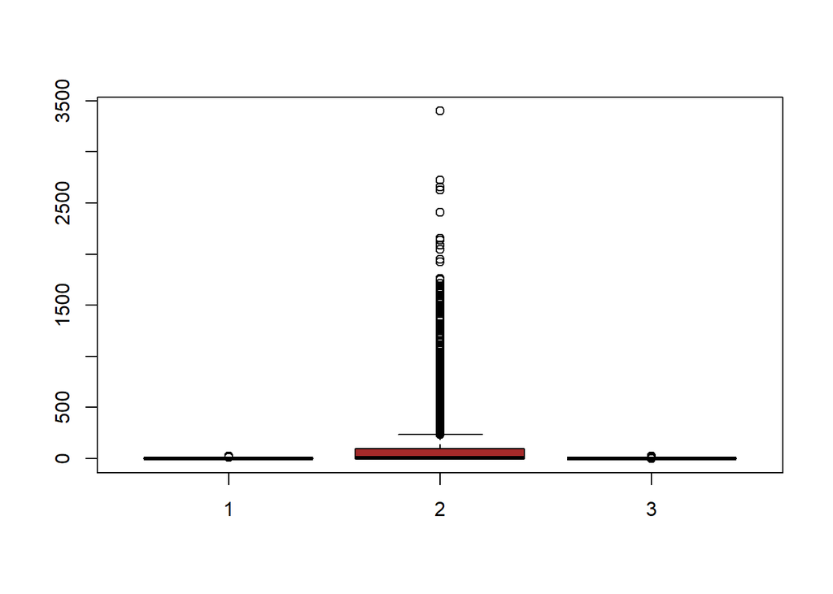

```r
boxplot(customer_df$Administrative,customer_df$Administrative_Duration,customer_df$Informational, col = "brown")
```

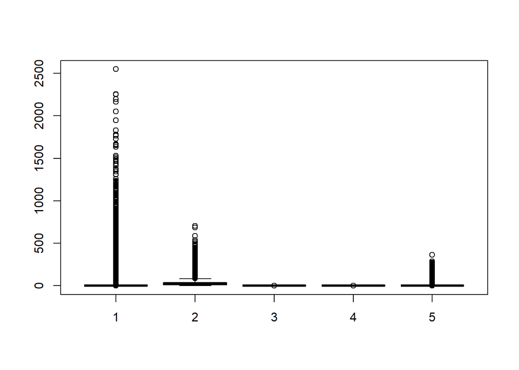

```r
boxplot(customer_df$Informational_Duration,customer_df$ProductRelated,customer_df$BounceRates,customer_df$ExitRates,customer_df$PageValues, col = "brown")
```

```r
outliers <- function(x) {

  Q1 <- quantile(x, probs=.25)
  Q3 <- quantile(x, probs=.75)
  iqr = Q3-Q1

 upper_limit = Q3 + (iqr*1.5)
 lower_limit = Q1 - (iqr*1.5)

 x > upper_limit | x < lower_limit
}

remove_outliers <- function(customer_df, cols = names(customer_df)) {
  for (col in cols) {
    customer_df <- customer_df[!outliers(customer_df[[col]]),]
  }
  customer_df
}
```

```r
dim(customer_df)
```

```
## [1] 12199    18
```

##Exploratory data analysis

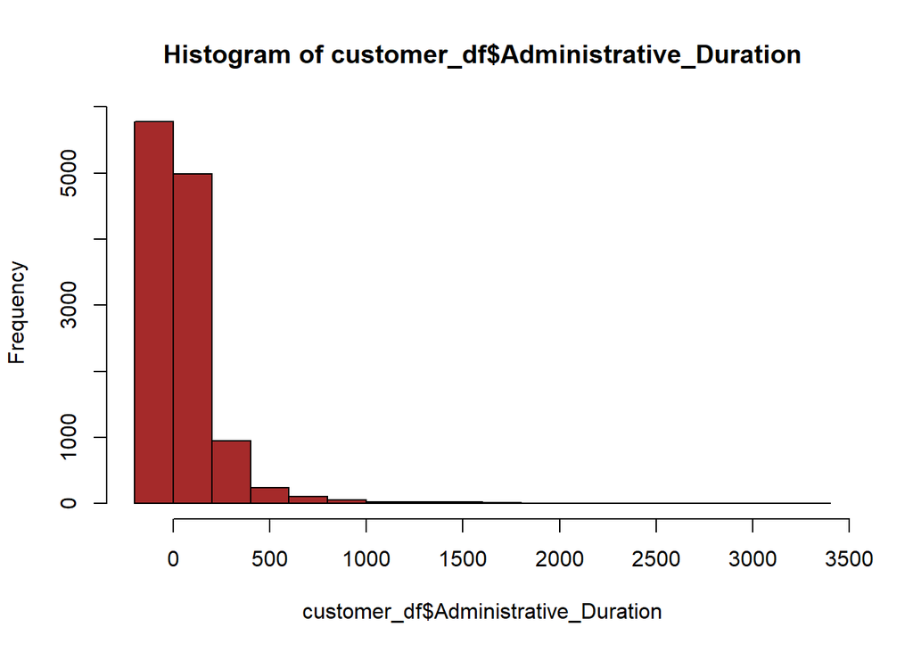

```r
hist(customer_df$Administrative_Duration,col = "brown")
```

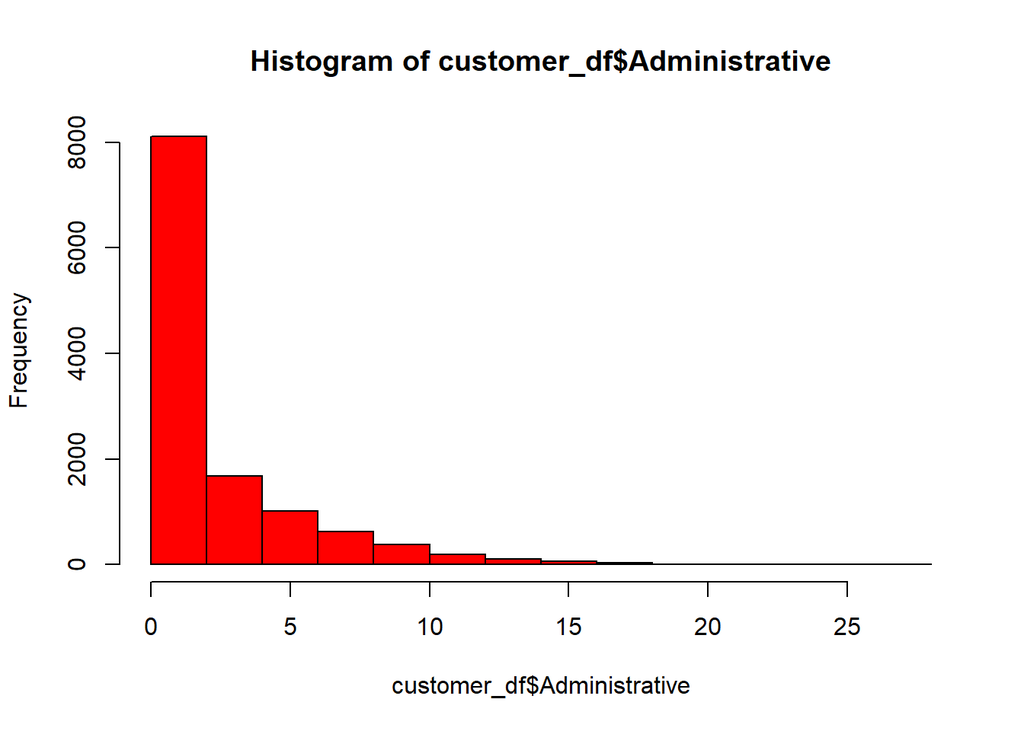

```r
hist(customer_df$Administrative, col = "red")
```

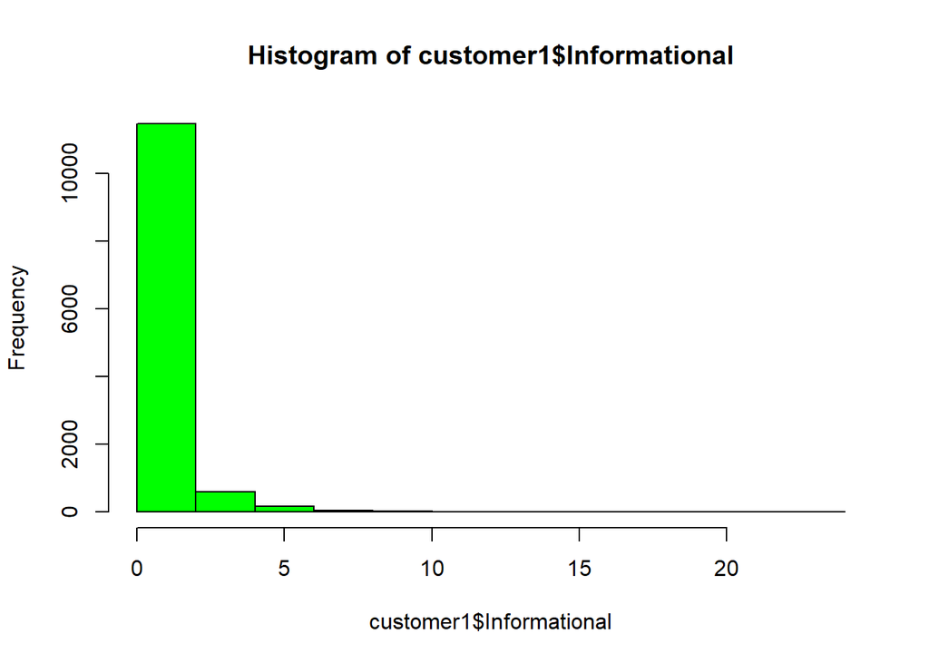

```r
hist(customer1$Informational,col="green")
```

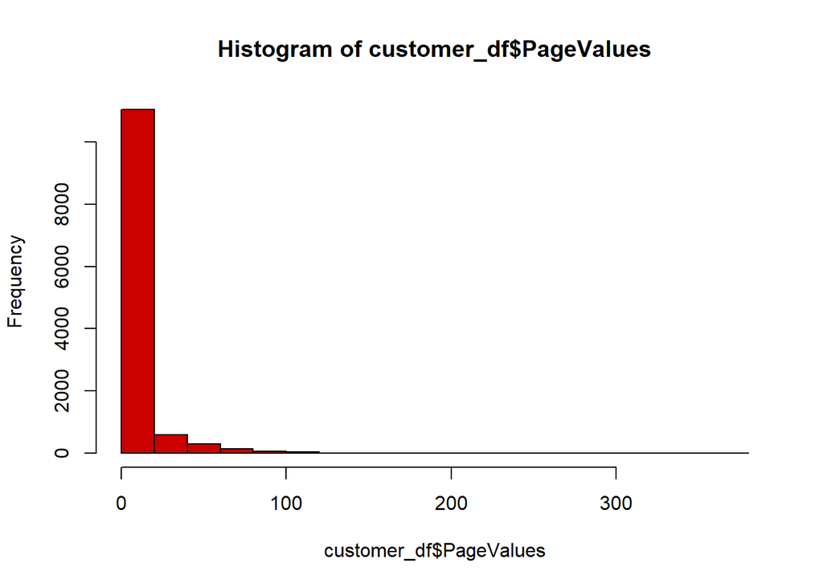

```r
hist(customer_df$PageValues,col = "red3")
```

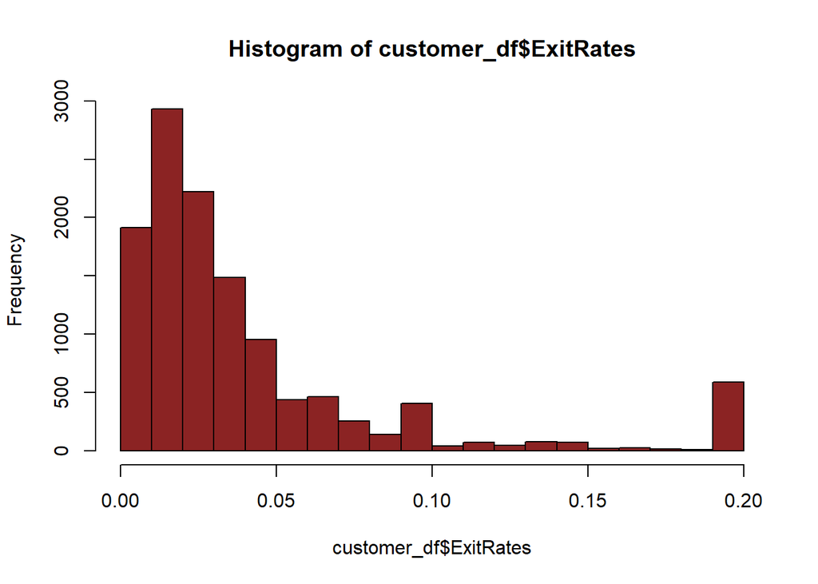

```r
hist(customer_df$ExitRates,col = "brown4")
```

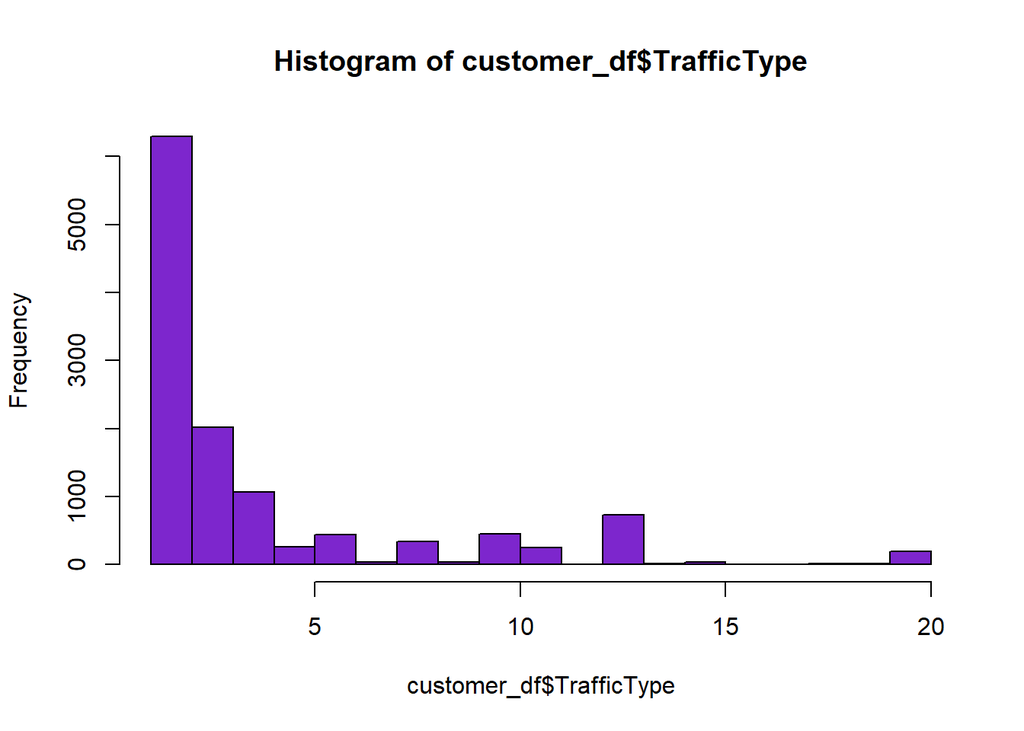

```r
hist(customer_df$TrafficType, col="purple3")
```

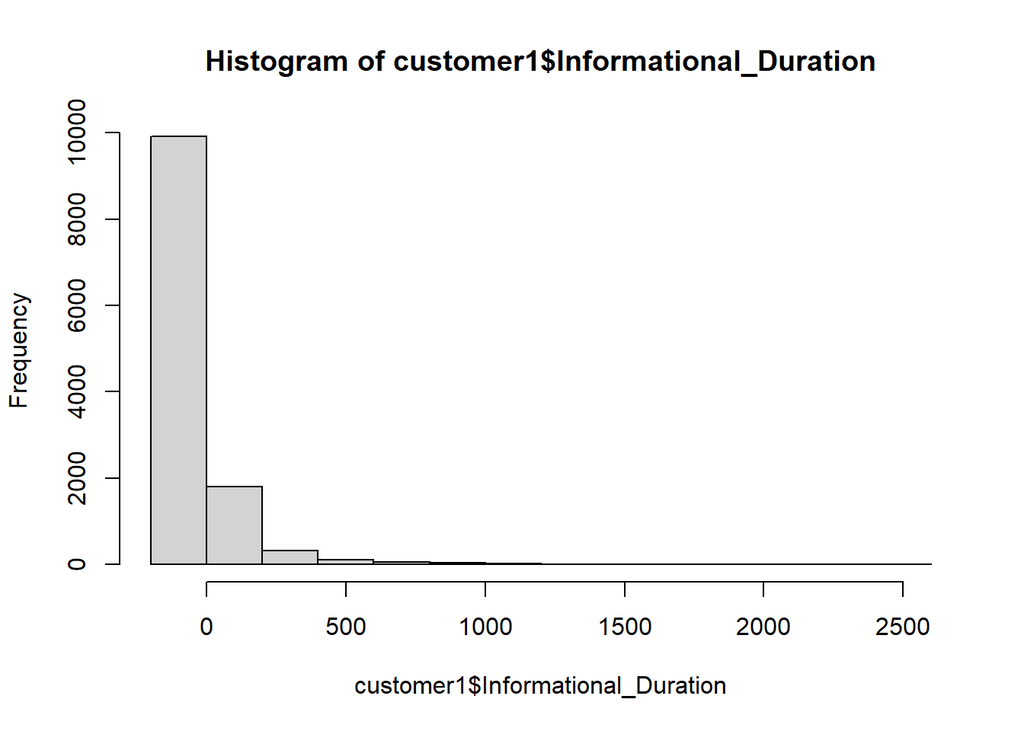

```r
#frequency plot to show the information duration distribution
hist(customer1$Informational_Duration)
```

*Bivariate Analysis*

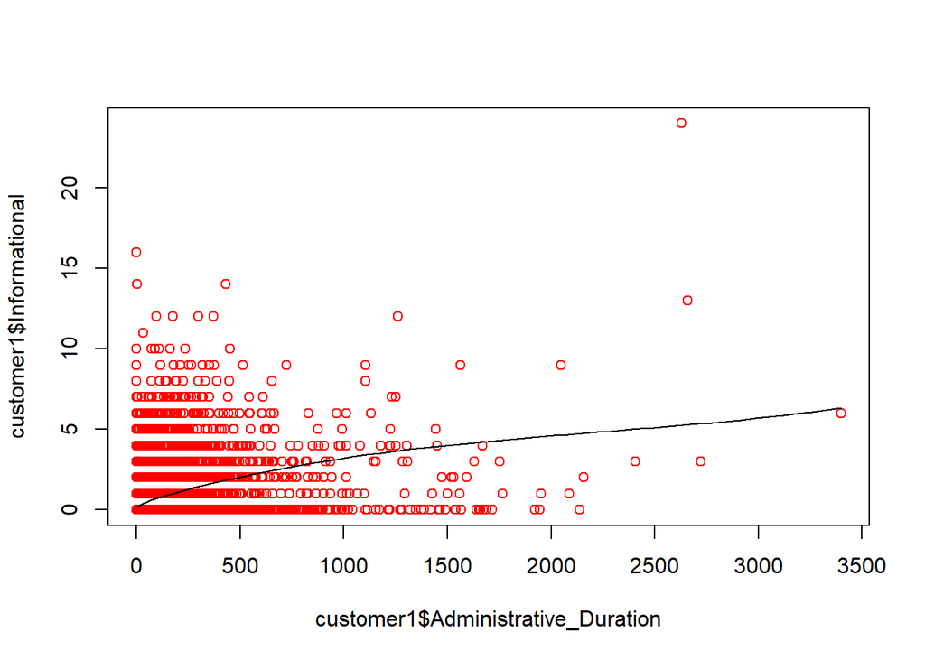

```r
#scatter plot to show the relationship between Age and Daily.internet usage
scatter.smooth(customer1$Administrative_Duration, customer1$Informational, col = "red")
```

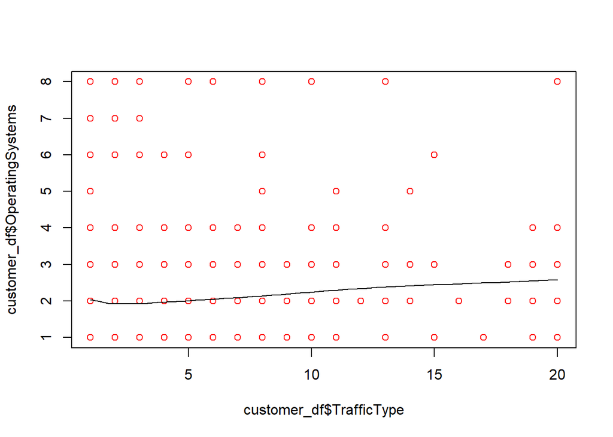

```r
scatter.smooth(customer_df$TrafficType,customer_df$OperatingSystems, col="red")
```

```r
unique(customer_df$Weekend)
```

```
## [1] FALSE  TRUE
```

```r
customer_df$Month<-factor(customer_df$Month,level=c("Feb","Mar","May","Oct","June","Jul","Aug","Nov","Sep","Dec"),label=c(2,3,5,10,6,7,8,11,9,12))
```

```r
customer_df$VisitorType<-factor(customer_df$VisitorType,level=c("Returning_Visitor","New_Visitor","Other"),label=c(1,2,3))
```

```r
customer_df$Weekend<-factor(customer_df$Weekend,level=c("FALSE","TRUE"),label=c(0,1))
```

```r
customer_df$Revenue<-factor(customer_df$Revenue,level=c("FALSE","TRUE"),label=c(0,1))
```

```r
#selecting numerical variables to check for presences of outliers
customer_data<-customer_df[,c(1,2,3,4,5,6,7,8,9,10,11,12,13,14,15,17,18)]
head(customer_data)
```

```
##   Administrative Administrative_Duration Informational Informational_Duration
## 1              0                       0             0                      0
## 2              0                       0             0                      0
## 3              0                      -1             0                     -1
## 4              0                       0             0                      0
## 5              0                       0             0                      0
## 6              0                       0             0                      0
##   ProductRelated ProductRelated_Duration BounceRates ExitRates PageValues
## 1              1                0.000000  0.20000000 0.2000000          0
## 2              2               64.000000  0.00000000 0.1000000          0
## 3              1               -1.000000  0.20000000 0.2000000          0
## 4              2                2.666667  0.05000000 0.1400000          0
## 5             10              627.500000  0.02000000 0.0500000          0
## 6             19              154.216667  0.01578947 0.0245614          0
##   SpecialDay Month OperatingSystems Browser Region TrafficType Weekend Revenue
## 1          0     2                1       1      1           1       0       0
## 2          0     2                2       2      1           2       0       0
## 3          0     2                4       1      9           3       0       0
## 4          0     2                3       2      2           4       0       0
## 5          0     2                3       3      1           4       1       0
## 6          0     2                2       2      1           3       0       0
```

```r
customer_data[,1:17]<-sapply(customer_data[,1:17],as.factor)
customer_data[,1:17]<-sapply(customer_data[,1:17],as.numeric)
str(customer_data)
```

```
## 'data.frame':    12199 obs. of  17 variables:
##  $ Administrative         : num  0 0 0 0 0 0 0 1 0 0 ...
##  $ Administrative_Duration: num  0 0 -1 0 0 0 -1 -1 0 0 ...
##  $ Informational          : num  0 0 0 0 0 0 0 0 0 0 ...
##  $ Informational_Duration : num  0 0 -1 0 0 0 -1 -1 0 0 ...
##  $ ProductRelated         : num  1 2 1 2 10 19 1 1 2 3 ...
##  $ ProductRelated_Duration: num  0 64 -1 2.67 627.5 ...
##  $ BounceRates            : num  0.2 0 0.2 0.05 0.02 ...
##  $ ExitRates              : num  0.2 0.1 0.2 0.14 0.05 ...
##  $ PageValues             : num  0 0 0 0 0 0 0 0 0 0 ...
##  $ SpecialDay             : num  0 0 0 0 0 0 0.4 0 0.8 0.4 ...
##  $ Month                  : num  2 2 2 2 2 2 2 2 2 2 ...
##  $ OperatingSystems       : num  1 2 4 3 3 2 2 1 2 2 ...
##  $ Browser                : num  1 2 1 2 3 2 4 2 2 4 ...
##  $ Region                 : num  1 1 9 2 1 1 3 1 2 1 ...
##  $ TrafficType            : num  1 2 3 4 4 3 3 5 3 2 ...
##  $ Weekend                : num  0 0 0 0 1 0 0 1 0 0 ...
##  $ Revenue                : num  0 0 0 0 0 0 0 0 0 0 ...
```

```r
#checking the correlation between columns using the pearson method
res2 <-cor.test(customer_data$ProductRelated,customer_data$ProductRelated_Duration,  method = "pearson")
res2
```

```
##
##  Pearson's product-moment correlation
##
## data:  customer_data$ProductRelated and customer_data$ProductRelated_Duration
## t = 186.38, df = 12197, p-value < 2.2e-16
## alternative hypothesis: true correlation is not equal to 0
## 95 percent confidence interval:
##  0.8556251 0.8648504
## sample estimates:
##       cor
## 0.8603082
```

```r
#checking the correlation between columns using the pearson method

res2 <-cor.test(customer_data$Administrative,customer_data$Administrative_Duration,  method = "pearson")
res2
```

```
##
##  Pearson's product-moment correlation
##
## data:  customer_data$Administrative and customer_data$Administrative_Duration
## t = 82.918, df = 12197, p-value < 2.2e-16
## alternative hypothesis: true correlation is not equal to 0
## 95 percent confidence interval:
##  0.5889389 0.6116386
## sample estimates:
##       cor
## 0.6004097
```

```r
#checking the correlation between columns using the pearson method

res2 <-cor.test(customer_data$BounceRates,customer_data$ExitRates,  method = "pearson")
res2
```

```
##
##  Pearson's product-moment correlation
##
## data:  customer_data$BounceRates and customer_data$ExitRates
## t = 232.62, df = 12197, p-value < 2.2e-16
## alternative hypothesis: true correlation is not equal to 0
## 95 percent confidence interval:
##  0.9000408 0.9065709
## sample estimates:
##       cor
## 0.9033582
```

```r
#plotting a correlatin plot show the relationship between the data points
library(corrplot)
mydata = cor(as.matrix(customer_data))
mydata
```

```
##                         Administrative Administrative_Duration Informational
## Administrative             1.000000000             0.600409653    0.37528761
## Administrative_Duration    0.600409653             1.000000000    0.30143630
## Informational              0.375287611             0.301436296    1.00000000
## Informational_Duration     0.254786021             0.237189860    0.61867795
## ProductRelated             0.428191515             0.286783914    0.37260472
## ProductRelated_Duration    0.371027224             0.353513793    0.38608372
## BounceRates               -0.213666635            -0.137333397   -0.10950530
## ExitRates                 -0.311274132            -0.202024452   -0.15956681
## PageValues                 0.096920968             0.066168365    0.04739015
## SpecialDay                -0.097072098            -0.074736885   -0.04937677
## Month                      0.093912709             0.055932944    0.06206237
## OperatingSystems          -0.006697922            -0.007610715   -0.00962587
## Browser                   -0.025763658            -0.015833675   -0.03876681
## Region                    -0.007262053            -0.006723711   -0.03047732
## TrafficType               -0.034784126            -0.015075015   -0.03518669
## Weekend                    0.024055542             0.013418049    0.03426835
## Revenue                    0.136203935             0.091688606    0.09360951
##                         Informational_Duration ProductRelated
## Administrative                     0.254786021    0.428191515
## Administrative_Duration            0.237189860    0.286783914
## Informational                      0.618677947    0.372604721
## Informational_Duration             1.000000000    0.279061948
## ProductRelated                     0.279061948    1.000000000
## ProductRelated_Duration            0.346580691    0.860308186
## BounceRates                       -0.070159472   -0.193515772
## ExitRates                         -0.102932678   -0.286163211
## PageValues                         0.030064160    0.054115494
## SpecialDay                        -0.031293040   -0.025930622
## Month                              0.043420471    0.153917511
## OperatingSystems                  -0.009749983    0.004090351
## Browser                           -0.019609349   -0.013706213
## Region                            -0.027920098   -0.040106501
## TrafficType                       -0.025163571   -0.044344333
## Weekend                            0.023253660    0.013725363
## Revenue                            0.069325050    0.155938463
##                         ProductRelated_Duration  BounceRates    ExitRates
## Administrative                      0.371027224 -0.213666635 -0.311274132
## Administrative_Duration             0.353513793 -0.137333397 -0.202024452
## Informational                       0.386083717 -0.109505298 -0.159566815
```

[output cut: 53 more lines]

```
## Informational            0.093609509
## Informational_Duration   0.069325050
## ProductRelated           0.155938463
## ProductRelated_Duration  0.149977332
## BounceRates             -0.145388056
## ExitRates               -0.204296874
## PageValues               0.491861168
## SpecialDay              -0.083672650
## Month                    0.126125957
## OperatingSystems        -0.014996447
## Browser                  0.023967286
## Region                  -0.012726874
## TrafficType             -0.005694599
## Weekend                  0.027875105
## Revenue                  1.000000000
```

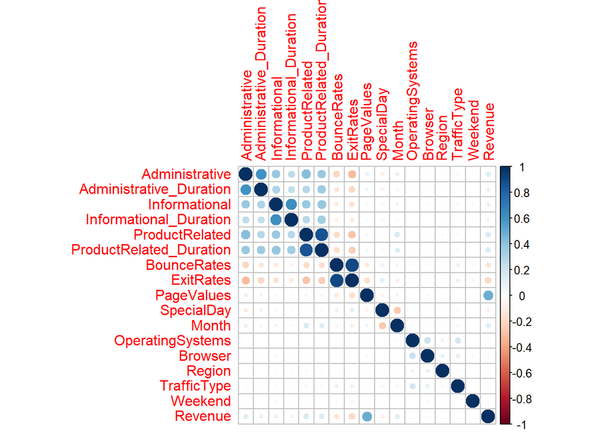

```r
corrplot(mydata)
```

```r
#plotting heatmap to show correlation between our data
mydata.rcorr = cor(as.matrix(customer_data))
mydata.rcorr
```

```
##                         Administrative Administrative_Duration Informational
## Administrative             1.000000000             0.600409653    0.37528761
## Administrative_Duration    0.600409653             1.000000000    0.30143630
## Informational              0.375287611             0.301436296    1.00000000
## Informational_Duration     0.254786021             0.237189860    0.61867795
## ProductRelated             0.428191515             0.286783914    0.37260472
## ProductRelated_Duration    0.371027224             0.353513793    0.38608372
## BounceRates               -0.213666635            -0.137333397   -0.10950530
## ExitRates                 -0.311274132            -0.202024452   -0.15956681
## PageValues                 0.096920968             0.066168365    0.04739015
## SpecialDay                -0.097072098            -0.074736885   -0.04937677
## Month                      0.093912709             0.055932944    0.06206237
## OperatingSystems          -0.006697922            -0.007610715   -0.00962587
## Browser                   -0.025763658            -0.015833675   -0.03876681
## Region                    -0.007262053            -0.006723711   -0.03047732
## TrafficType               -0.034784126            -0.015075015   -0.03518669
## Weekend                    0.024055542             0.013418049    0.03426835
## Revenue                    0.136203935             0.091688606    0.09360951
##                         Informational_Duration ProductRelated
## Administrative                     0.254786021    0.428191515
## Administrative_Duration            0.237189860    0.286783914
## Informational                      0.618677947    0.372604721
## Informational_Duration             1.000000000    0.279061948
## ProductRelated                     0.279061948    1.000000000
## ProductRelated_Duration            0.346580691    0.860308186
## BounceRates                       -0.070159472   -0.193515772
## ExitRates                         -0.102932678   -0.286163211
## PageValues                         0.030064160    0.054115494
## SpecialDay                        -0.031293040   -0.025930622
## Month                              0.043420471    0.153917511
## OperatingSystems                  -0.009749983    0.004090351
## Browser                           -0.019609349   -0.013706213
## Region                            -0.027920098   -0.040106501
## TrafficType                       -0.025163571   -0.044344333
## Weekend                            0.023253660    0.013725363
## Revenue                            0.069325050    0.155938463
##                         ProductRelated_Duration  BounceRates    ExitRates
## Administrative                      0.371027224 -0.213666635 -0.311274132
## Administrative_Duration             0.353513793 -0.137333397 -0.202024452
## Informational                       0.386083717 -0.109505298 -0.159566815
```

[output cut: 53 more lines]

```
## Informational            0.093609509
## Informational_Duration   0.069325050
## ProductRelated           0.155938463
## ProductRelated_Duration  0.149977332
## BounceRates             -0.145388056
## ExitRates               -0.204296874
## PageValues               0.491861168
## SpecialDay              -0.083672650
## Month                    0.126125957
## OperatingSystems        -0.014996447
## Browser                  0.023967286
## Region                  -0.012726874
## TrafficType             -0.005694599
## Weekend                  0.027875105
## Revenue                  1.000000000
```

[figure not shown]

```r
heatmap(mydata.rcorr, col = palette, symm = TRUE)
```

##Implenting the solution

```r
dim(customer_data)
```

```
## [1] 12199    17
```

*K means clustering*

```r
customer.new<- customer_data[, c(1, 2, 3, 4,5,6,7,8,9,10,11,12,13,14,15,16)]
customer.class<- customer_data[, "Revenue"]
head(customer.new)
```

```
##   Administrative Administrative_Duration Informational Informational_Duration
## 1              0                       0             0                      0
## 2              0                       0             0                      0
## 3              0                      -1             0                     -1
## 4              0                       0             0                      0
## 5              0                       0             0                      0
## 6              0                       0             0                      0
##   ProductRelated ProductRelated_Duration BounceRates ExitRates PageValues
## 1              1                0.000000  0.20000000 0.2000000          0
## 2              2               64.000000  0.00000000 0.1000000          0
## 3              1               -1.000000  0.20000000 0.2000000          0
## 4              2                2.666667  0.05000000 0.1400000          0
## 5             10              627.500000  0.02000000 0.0500000          0
## 6             19              154.216667  0.01578947 0.0245614          0
##   SpecialDay Month OperatingSystems Browser Region TrafficType Weekend
## 1          0     2                1       1      1           1       0
## 2          0     2                2       2      1           2       0
## 3          0     2                4       1      9           3       0
## 4          0     2                3       2      2           4       0
## 5          0     2                3       3      1           4       1
## 6          0     2                2       2      1           3       0
```

```r
# Normalizing the dataset so that no particular attribute
#brings biased to our data
# ---
#
normalize <- function(x){
  return ((x-min(x)) / (max(x)-min(x)))
}

customer.new$Administrative <- normalize(customer.new$Administrative)
customer.new$Administrative_Duration<- normalize(customer.new$Administrative_Duration)
customer.new$Informational<- normalize(customer.new$Informational)
customer.new$Informational_Duration<- normalize(customer.new$Informational_Duration)
customer.new$ProductRelated <- normalize(customer.new$ProductRelated)
customer.new$ProductRelated_Duration<- normalize(customer.new$ProductRelated_Duration)
customer.new$BounceRates<- normalize(customer.new$BounceRates)
customer.new$ExitRates<- normalize(customer.new$ExitRates)
customer.new$PageValues <- normalize(customer.new$PageValues)
customer.new$SpecialDay<- normalize(customer.new$SpecialDay)
customer.new$Month<- normalize(customer.new$Month)
customer.new$OperatingSystems<- normalize(customer.new$OperatingSystems)
customer.new$Browser<-normalize(customer.new$Browser)
customer.new$Region<- normalize(customer.new$Region)
customer.new$TrafficType<- normalize(customer.new$TrafficType)
customer.new$Weekend<- normalize(customer.new$Weekend)
head(customer.new)
```

```
##   Administrative Administrative_Duration Informational Informational_Duration
## 1              0            0.0002941393             0           0.0003920992
## 2              0            0.0002941393             0           0.0003920992
## 3              0            0.0000000000             0           0.0000000000
## 4              0            0.0002941393             0           0.0003920992
## 5              0            0.0002941393             0           0.0003920992
## 6              0            0.0002941393             0           0.0003920992
##   ProductRelated ProductRelated_Duration BounceRates ExitRates PageValues
## 1    0.001418440            1.563122e-05  1.00000000  1.000000          0
## 2    0.002836879            1.016029e-03  0.00000000  0.500000          0
## 3    0.001418440            0.000000e+00  1.00000000  1.000000          0
## 4    0.002836879            5.731448e-05  0.25000000  0.700000          0
## 5    0.014184397            9.824223e-03  0.10000000  0.250000          0
## 6    0.026950355            2.426226e-03  0.07894737  0.122807          0
##   SpecialDay Month OperatingSystems    Browser Region TrafficType Weekend
## 1          0     0        0.0000000 0.00000000  0.000  0.00000000       0
## 2          0     0        0.1428571 0.08333333  0.000  0.05263158       0
## 3          0     0        0.4285714 0.00000000  1.000  0.10526316       0
## 4          0     0        0.2857143 0.08333333  0.125  0.15789474       0
## 5          0     0        0.2857143 0.16666667  0.000  0.15789474       1
## 6          0     0        0.1428571 0.08333333  0.000  0.10526316       0
```

```r
set.seed(123)

customers_dataset <- kmeans(customer_data, centers = 5, nstart = 25)
print(customers_dataset)
```

```
## K-means clustering with 5 clusters of sizes 8173, 2962, 188, 10, 866
##
## Cluster means:
##   Administrative Administrative_Duration Informational Informational_Duration
## 1       1.555365                49.70366     0.2504588               13.59052
## 2       3.379811               126.02079     0.8014855               55.43125
## 3       7.106383               231.82970     2.5585106              230.65455
## 4      14.700000              1558.19631     7.4000000             1034.03250
## 5       5.011547               182.18588     1.4214781              110.87134
##   ProductRelated ProductRelated_Duration BounceRates  ExitRates PageValues
## 1       14.17925                381.3743 0.026590253 0.05056900   4.725833
## 2       46.77313               1854.8323 0.008397891 0.02376774   8.910370
## 3      226.34043              10030.9208 0.006072151 0.01996420   4.396991
## 4      512.40000              30277.9524 0.004504685 0.01839164   3.543312
## 5      102.74365               4539.0465 0.006982011 0.02145683   7.777986
```

[output cut: 1901 more lines]

```r
head(customers_dataset$cluster)
```

```
## 1 2 3 4 5 6
## 1 1 1 1 1 1
```

```r
head(customers_dataset$centers)
```

```
##   Administrative Administrative_Duration Informational Informational_Duration
## 1       1.555365                49.70366     0.2504588               13.59052
## 2       3.379811               126.02079     0.8014855               55.43125
## 3       7.106383               231.82970     2.5585106              230.65455
## 4      14.700000              1558.19631     7.4000000             1034.03250
## 5       5.011547               182.18588     1.4214781              110.87134
##   ProductRelated ProductRelated_Duration BounceRates  ExitRates PageValues
## 1       14.17925                381.3743 0.026590253 0.05056900   4.725833
## 2       46.77313               1854.8323 0.008397891 0.02376774   8.910370
## 3      226.34043              10030.9208 0.006072151 0.01996420   4.396991
## 4      512.40000              30277.9524 0.004504685 0.01839164   3.543312
## 5      102.74365               4539.0465 0.006982011 0.02145683   7.777986
##   SpecialDay    Month OperatingSystems  Browser   Region TrafficType   Weekend
## 1 0.06636486 7.384437         2.117827 2.366573 3.166157    4.202618 0.2313716
## 2 0.05435517 7.972654         2.136394 2.340311 3.193788    3.879473 0.2410533
## 3 0.03191489 9.478723         2.170213 2.340426 2.585106    3.526596 0.2606383
## 4 0.00000000 9.500000         1.900000 2.100000 1.500000    6.000000 0.1000000
## 5 0.05381062 8.918014         2.137413 2.346420 3.035797    3.630485 0.2321016
##     Revenue
## 1 0.1170929
## 2 0.2153950
## 3 0.3351064
## 4 0.2000000
## 5 0.2863741
```

```r
head(customers_dataset$size)
```

```
## [1] 8173 2962  188   10  866
```

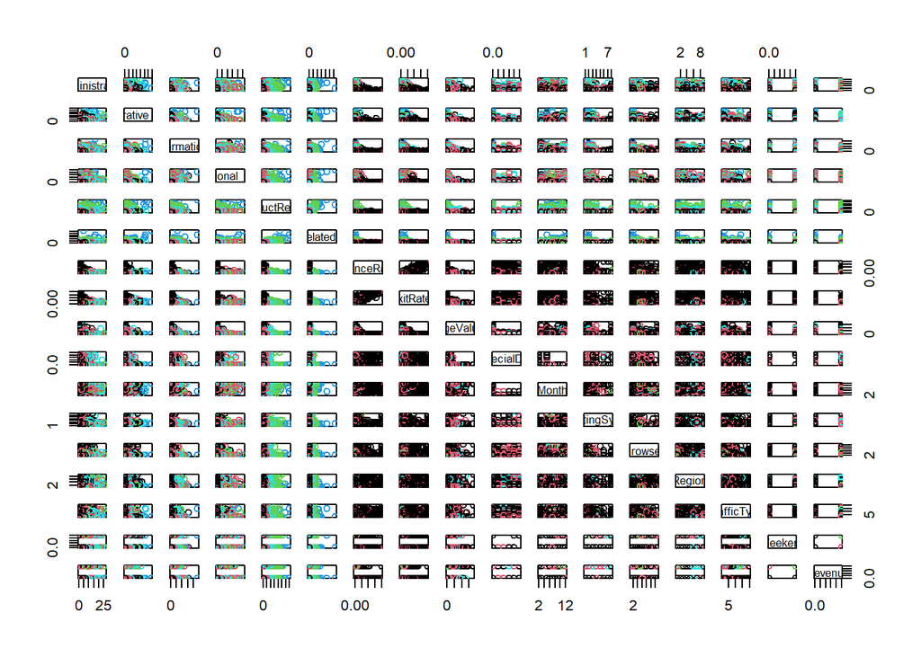

```r
# Visualizing the  clustering results

#
par(mfrow = c(1,2), mar = c(5,4,2,2))

#
plot(customer_data[,1:17], col = customers_dataset$cluster)
```

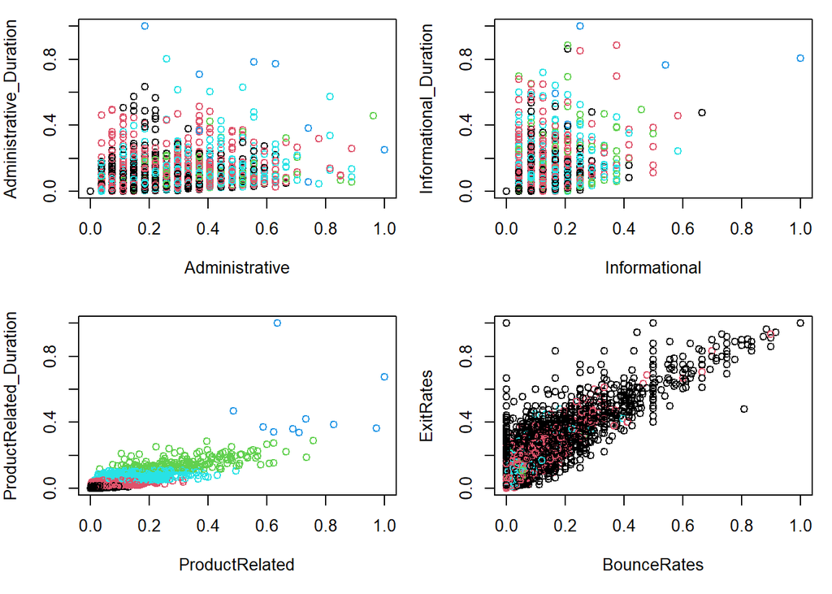

```r
# Verifying the results of clustering
# ---
#
par(mfrow = c(2,2), mar = c(5,4,1,1))

# Plotting to see how different  have been distributed in clusters
plot(customer.new[c(1,2)], col = customers_dataset$cluster)
plot(customer.new[c(3,4)], col = customers_dataset$cluster)
plot(customer.new[c(5,6)], col = customers_dataset$cluster)
plot(customer.new[c(7,8)], col = customers_dataset$cluster)
```

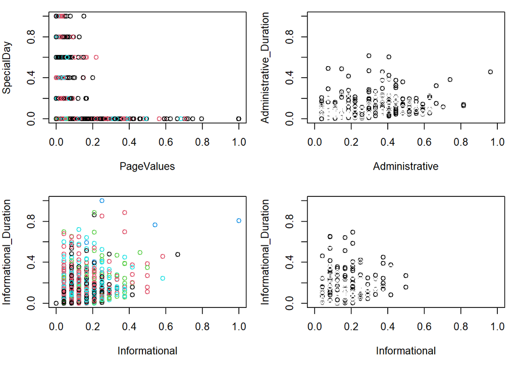

```r
plot(customer.new[c(9,10)], col = customers_dataset$cluster)
#ploting to see how different variables are distributed
# ---
#
plot(customer.new[c(1,2)], col = customer.class)

# Plotting to see how different columns are distributed in the clusters
# ---
#
plot(customer.new[c(3,4)], col = customers_dataset$cluster)
plot(customer.new[c(3,4)], col = customer.class)
```

##Hirarchial clustering

*scalling our data*

```r
#scaling our data to avoid biases
head(scale(customer_data))
```

```
##   Administrative Administrative_Duration Informational Informational_Duration
## 1     -0.7025315              -0.4601081    -0.3988128             -0.2462725
## 2     -0.7025315              -0.4601081    -0.3988128             -0.2462725
## 3     -0.7025315              -0.4657410    -0.3988128             -0.2533417
## 4     -0.7025315              -0.4601081    -0.3988128             -0.2462725
## 5     -0.7025315              -0.4601081    -0.3988128             -0.2462725
## 6     -0.7025315              -0.4601081    -0.3988128             -0.2462725
##   ProductRelated ProductRelated_Duration  BounceRates  ExitRates PageValues
## 1     -0.6963635              -0.6289343  3.954699721  3.4273070 -0.3190356
## 2     -0.6739424              -0.5955997 -0.450343788  1.2650121 -0.3190356
## 3     -0.6963635              -0.6294551  3.954699721  3.4273070 -0.3190356
## 4     -0.6739424              -0.6275453  0.650917089  2.1299300 -0.3190356
## 5     -0.4945739              -0.3020990 -0.009839437  0.1838646 -0.3190356
## 6     -0.2927843              -0.5486101 -0.102577188 -0.3661929 -0.3190356
##   SpecialDay     Month OperatingSystems    Browser     Region TrafficType
## 1 -0.3103105 -1.674519       -1.2396607 -0.7939682 -0.8962939 -0.76562243
## 2 -0.3103105 -1.674519       -0.1371074 -0.2093703 -0.8962939 -0.51660683
## 3 -0.3103105 -1.674519        2.0679992 -0.7939682  2.4336556 -0.26759123
## 4 -0.3103105 -1.674519        0.9654459 -0.2093703 -0.4800502 -0.01857564
## 5 -0.3103105 -1.674519        0.9654459  0.3752276 -0.8962939 -0.01857564
## 6 -0.3103105 -1.674519       -0.1371074 -0.2093703 -0.8962939 -0.26759123
##      Weekend    Revenue
## 1 -0.5528638 -0.4305688
## 2 -0.5528638 -0.4305688
## 3 -0.5528638 -0.4305688
## 4 -0.5528638 -0.4305688
## 5  1.8086156 -0.4305688
## 6 -0.5528638 -0.4305688
```

```r
library(tidyverse)  # data manipulation
library(cluster)    # clustering algorithms
library(factoextra) # clustering visualization
library(dendextend)
df <- dist(customer_data, method = "euclidean")
```

```r
cut_df <- hclust(df, method = "ward.D2" )
```

```r
sub_grp <- cutree(cut_df, k = 5)

# Number of members in each cluster
table(sub_grp)
```

```
## sub_grp
##    1    2    3    4    5
## 7770 3845  518   64    2
```

*pltting the dendagram*

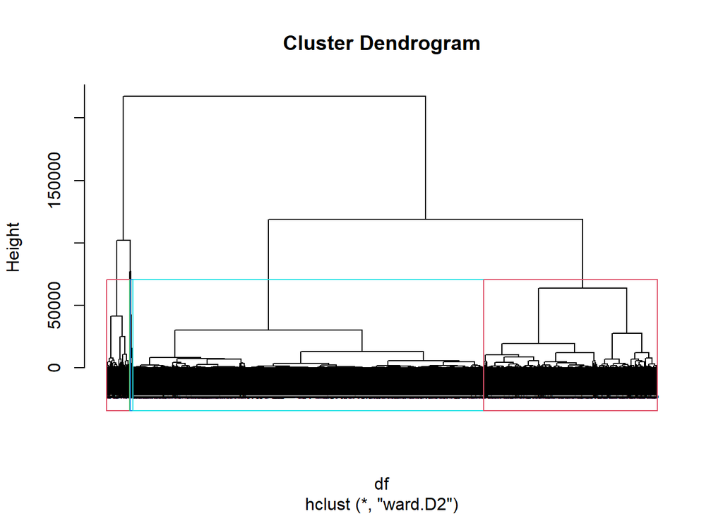

```r
plot(cut_df, cex = 0.01)
rect.hclust(cut_df, k = 5, border = 2:5)
```

***DBSCAN CLUSTERING

```r
library("dbscan")
```

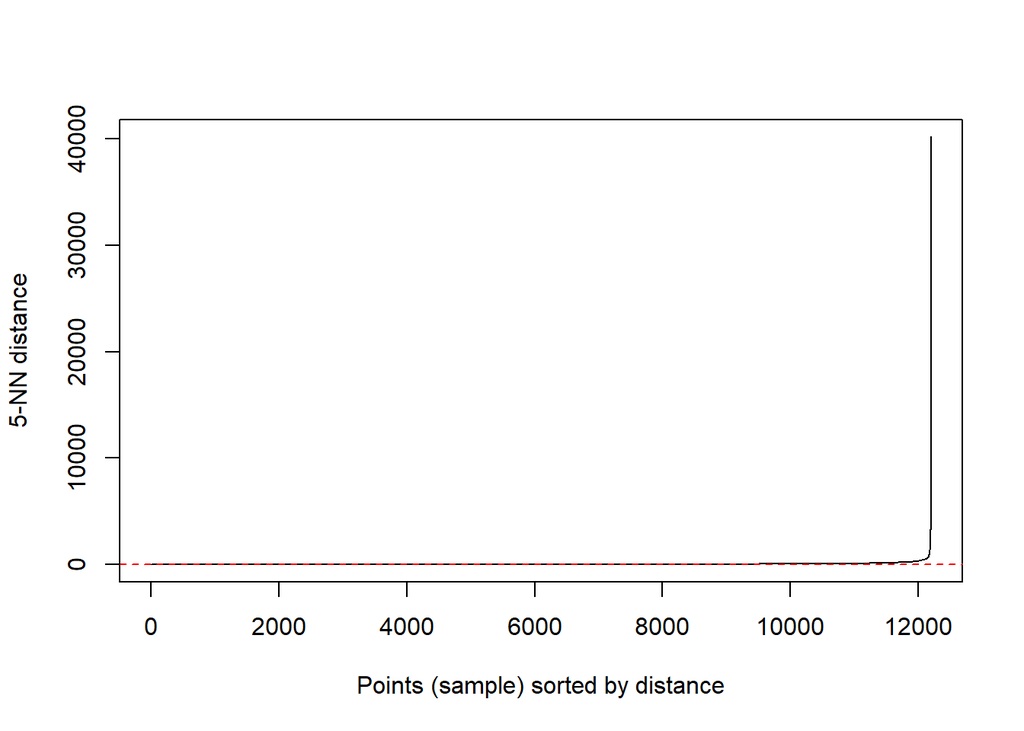

```r
kNNdistplot(customer_data, k = 5)
abline(h=.5, col = "red", lty=2)
```

```r
db<-dbscan(customer.new,eps=0.7,MinPts = 7)
db
```

```
## DBSCAN clustering for 12199 objects.
## Parameters: eps = 0.7, minPts = 7
## The clustering contains 3 cluster(s) and 13 noise points.
##
##    0    1    2    3
##   13 9335 2691  160
##
## Available fields: cluster, eps, minPts
```

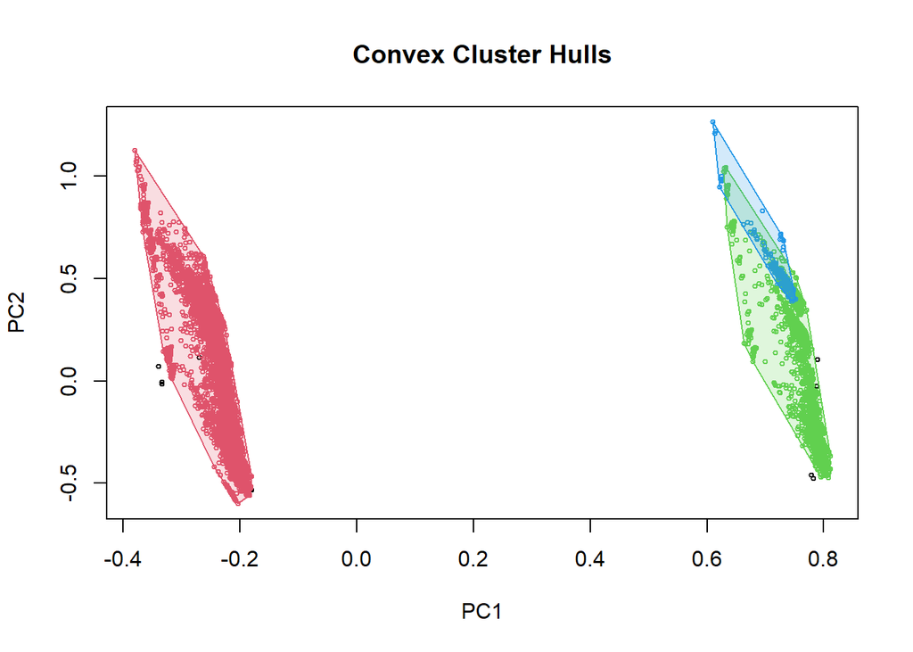

```r
# We also plot our clusters as shown
# ---
# The dataset and cluster method of dbscan is used to plot the clusters.
#
hullplot(customer.new,db$cluster)
```